Timeframe: From: 2022-01-03 To: 2022-06-24

# 1 Sales funnel

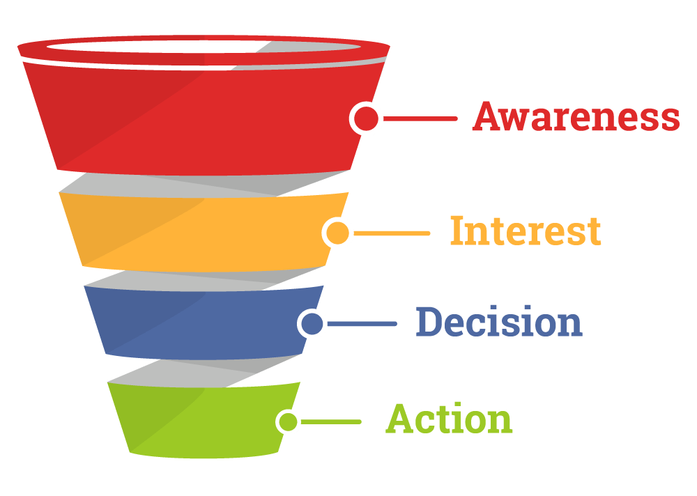

**Awareness**:

KPI: Unique users per 30 days  
Sekundær KPI: Brand awareness (fb likes, shares, mentions, trustpilot etc)

Aktuelt: 993

**Interest**:

KPI: Landing page bounce rate  
Aktuelt: 59.13%

**Decision and action**:

KPI: Conversion past 30 days  
Aktuelt: 4.33%

**Ad campaigns**:

KPI: ROAS  
Aktuelt for maj: 4.41

**OBS** Når mere trafik kommer fra non-paid sources skal beregning limites til paid traffic

# 2 Awareness

## 2.1 New users over time

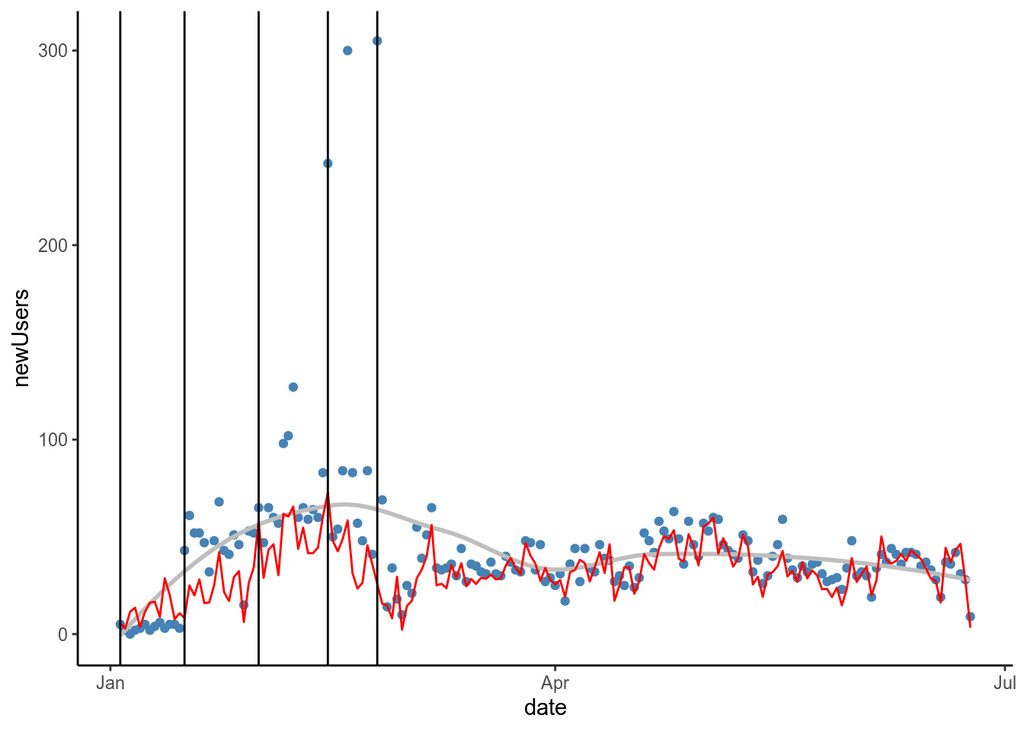

## 2.2 Top 10 sources of new users

| sourceMedium | newusers | percent |
| --- | --- | --- |
| google / cpc | 6628 | 87.78 |
| (direct) / (none) | 628 | 8.32 |
| google / organic | 143 | 1.89 |
| facebook.com / referral | 32 | 0.42 |
| baidu.com / referral | 25 | 0.33 |
| trustpilot / company_profile | 23 | 0.30 |
| l.instagram.com / referral | 16 | 0.21 |
| m.facebook.com / referral | 15 | 0.20 |
| bing / organic | 13 | 0.17 |
| duckduckgo / organic | 8 | 0.11 |

## 2.3 Devices of new users

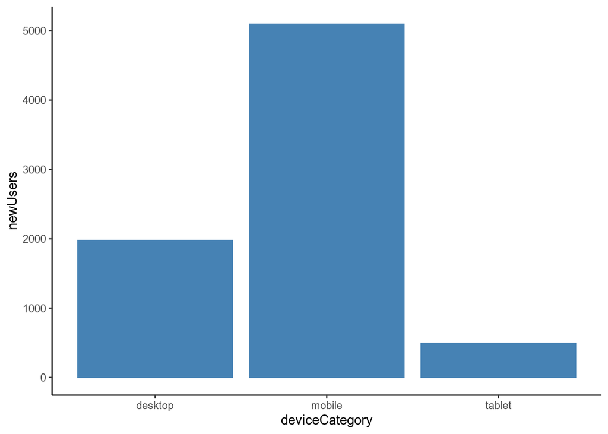

## 2.4 Age and gender distribution of new users

**Obs**: Lavere sample size da der ikke er alder på alle

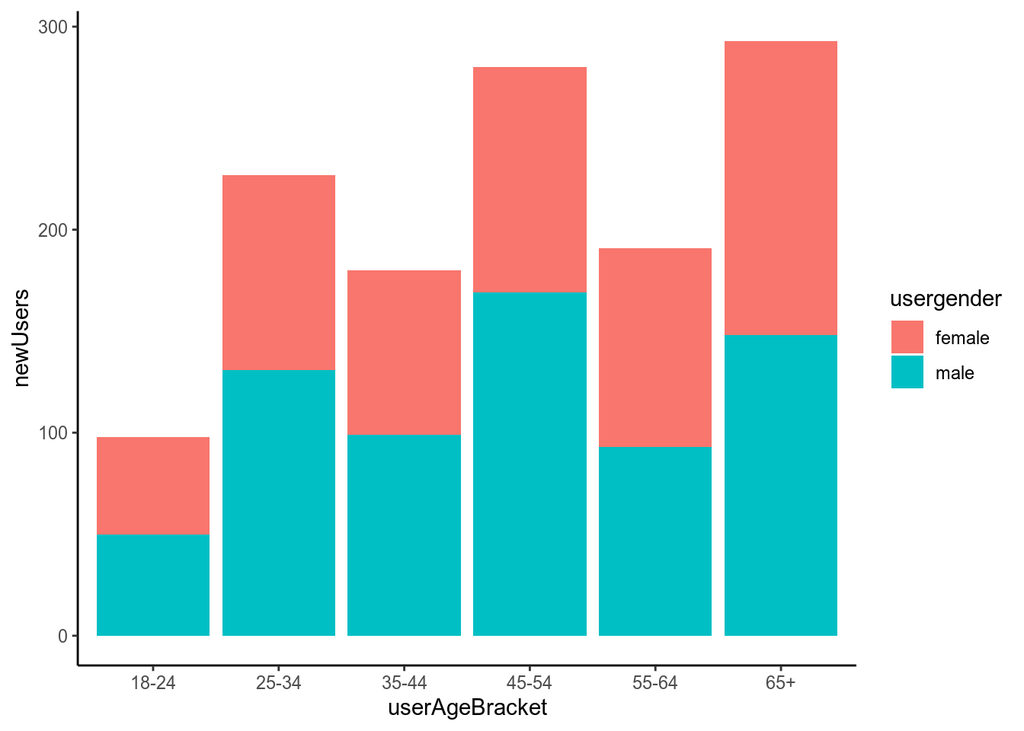

# 3 Interest

## 3.1 Landing page bounce rates per device

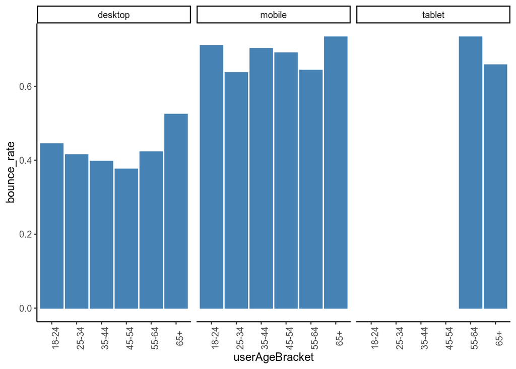

# 4 Decision and action

## 4.1 Conversion rate over time

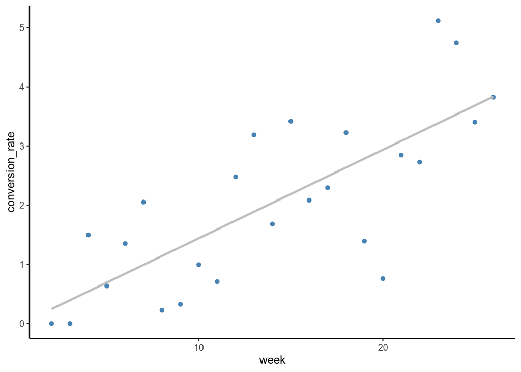

## 4.2 Conversion rate over time per agebracket

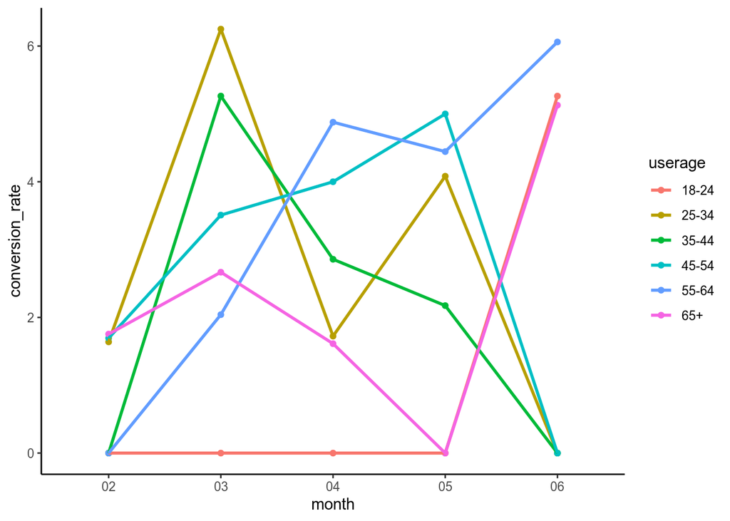

## 4.3 Conversion rates per agebracket and gender

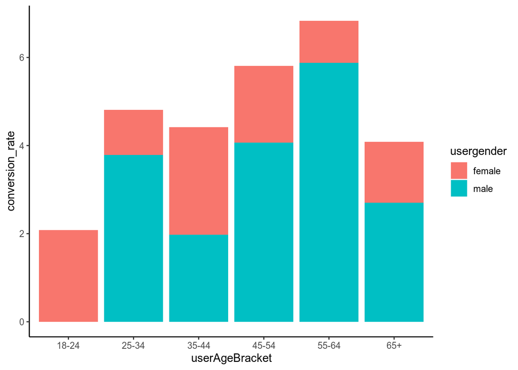

Fishers exact test

```
    Fisher's Exact Test for Count Data

data:  .
p-value = 0.05
alternative hypothesis: true odds ratio is not equal to 1
95 percent confidence interval:
 0.99 5.51
sample estimates:
odds ratio
       2.2
```

## 4.4 Conversion rates per agebracket per device

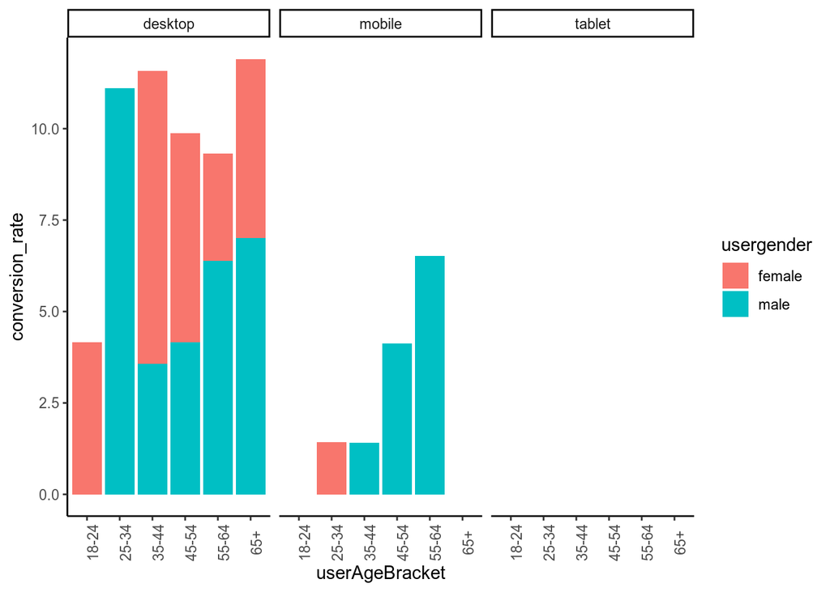

## 4.5 Conversion rates new vs returning visitor per device

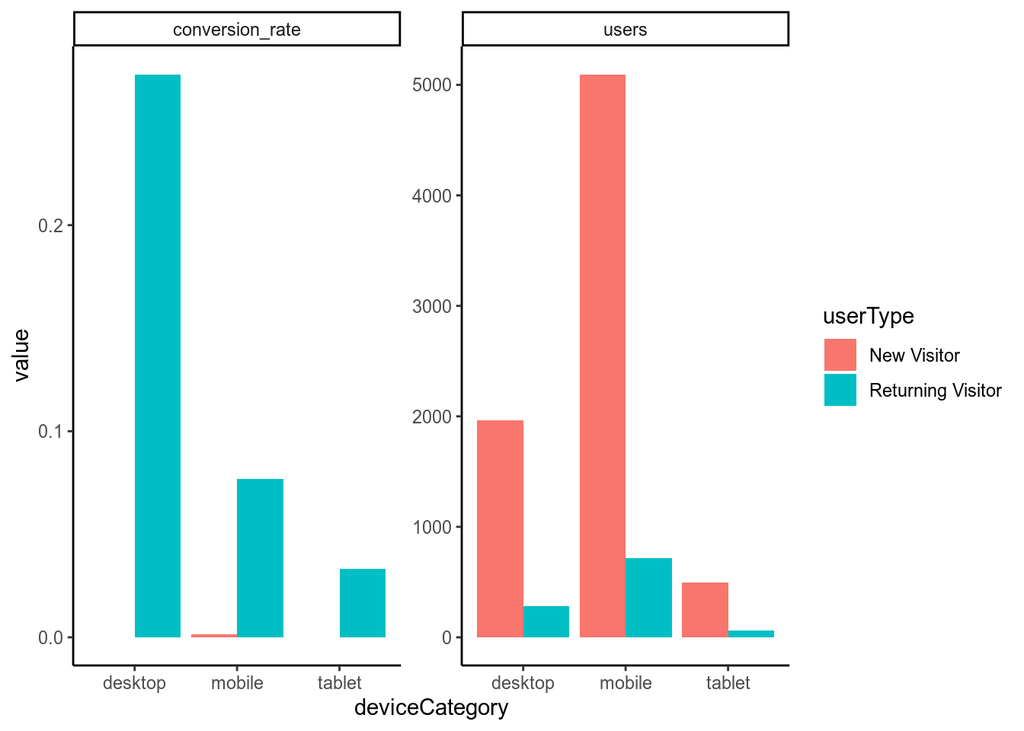

## 4.6 Products sold

| productName | revenue | proportion |
| --- | --- | --- |
| Standard | 14523 | 62.03 |
| Glidende overgang | 8493 | 36.27 |
| Solbriller | 311 | 1.33 |
| Brillereparation | 87 | 0.37 |

## 4.7 Cart abandonment

[output not shown]

# 5 Ad campaigns

## 5.1 ROAS over time

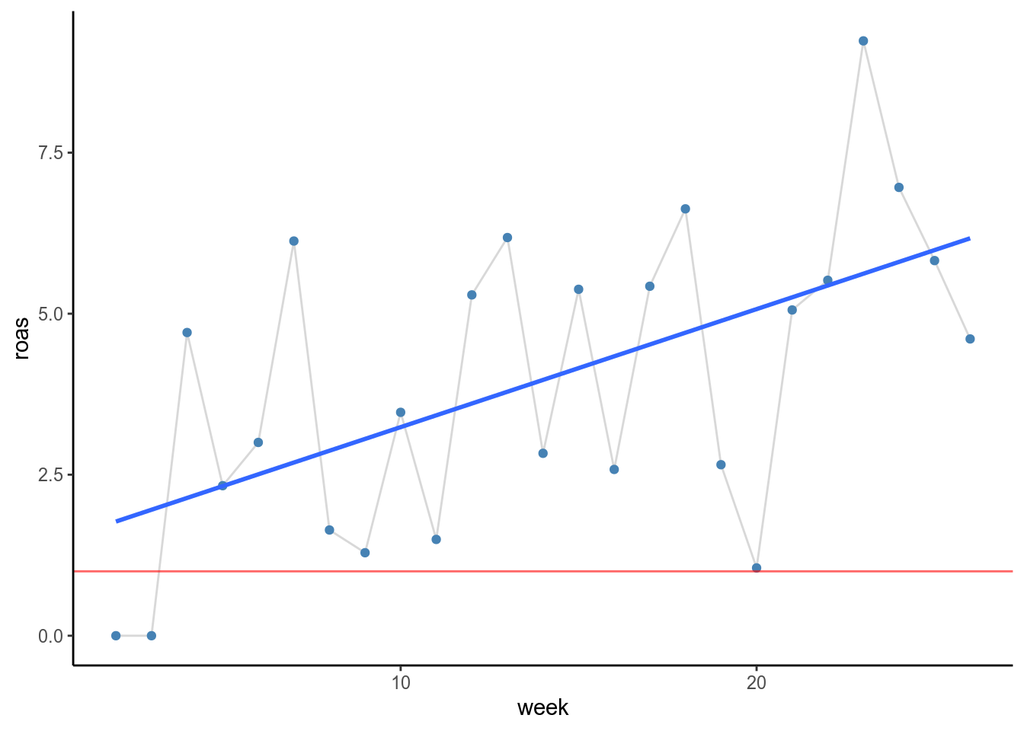

overall roas: 4.17

## 5.2 ROAS per agebracket

**OBS:**Meget lidt data ifht proportionen af transactions per agebracket

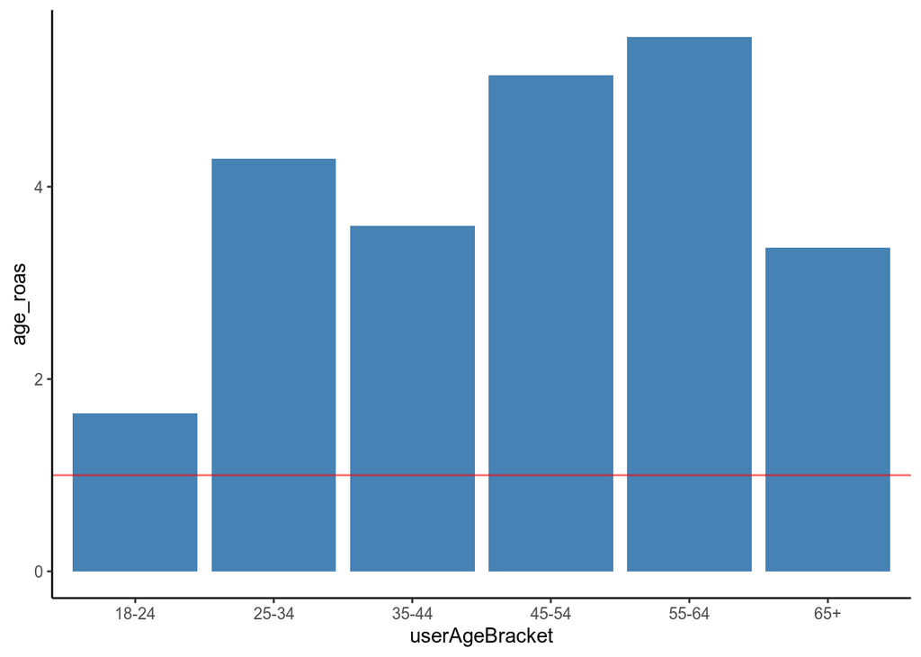

## 5.3 Roas per product group

**OBS:** Er uden display ads

| productName | adCost | revenue | product_roas |
| --- | --- | --- | --- |
| Glidende overgang | 471 | 8493 | 18.04 |
| Standard | 4124 | 14523 | 3.52 |
| Solbriller | 723 | 311 | 0.43 |

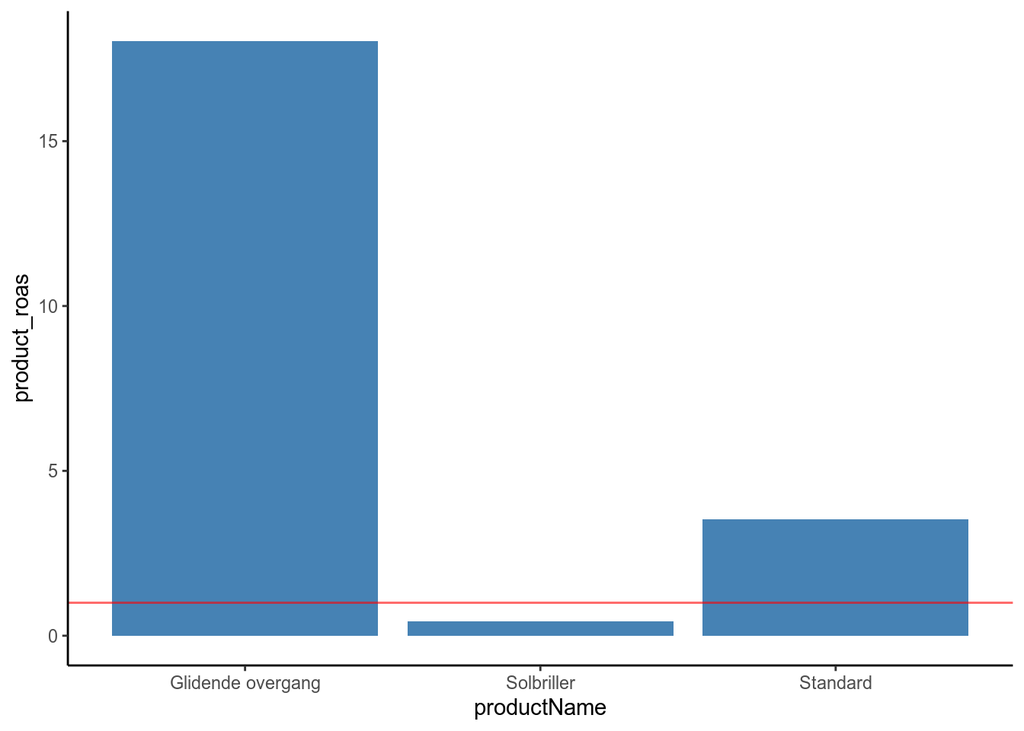

## 5.4 Average ROI per transaction

| transactions | total_adcost | total_rev | avg_rev | avg_adcost | avg_roi |
| --- | --- | --- | --- | --- | --- |
| 141 | 5610 | 23414 | 166 | 40 | 126 |

## 5.5 Cost per conversion over time

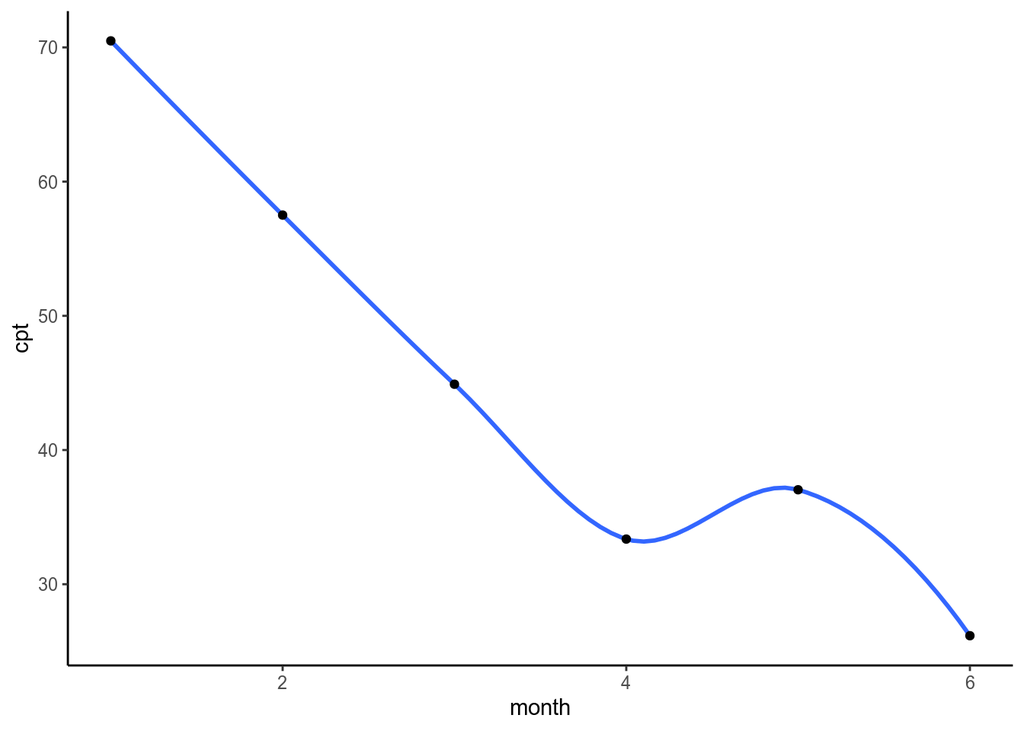

**OBS** Der er et disconnect mellem conversions og google ads keywords -> formentlig fordi det kun er starten på path

| medium | sourceMedium | transactions |
| --- | --- | --- |
| direct | (direct) / (none) | 0 |
| trustpilot | trustpilot / company_profile | 0 |
| google ads | google / cpc | 0 |
| organic | bing / organic | 0 |
| organic | duckduckgo / organic | 0 |
| organic | ecosia.org / organic | 0 |
| organic | google / organic | 0 |
| organic | yahoo / organic | 0 |
| referral | adclick.g.doubleclick.net / referral | 0 |
| referral | ads.google.com / referral | 0 |

[output cut: 12 more lines]

# 6 Keywords

## 6.1 Most impressions

| keyword | impressions | adClicks | adCost | bounces | ctr | bounce_rate | cost_per_click |
| --- | --- | --- | --- | --- | --- | --- | --- |
| (not set) | 208533 | 1998 | 170 | 2024 | 0.96 | 1.01 | 0.085 |
| brilleglas | 14262 | 1144 | 1090 | 742 | 8.02 | 0.65 | 0.953 |
| priser på brilleglas | 11063 | 471 | 239 | 290 | 4.26 | 0.62 | 0.507 |
| glidende overgang | 4981 | 294 | 267 | 212 | 5.90 | 0.72 | 0.908 |
| glas til briller | 4641 | 258 | 145 | 154 | 5.56 | 0.60 | 0.561 |
| briller glas | 4190 | 503 | 475 | 287 | 12.00 | 0.57 | 0.945 |
| nye brilleglas i gammelt stel | 4085 | 340 | 326 | 203 | 8.32 | 0.60 | 0.960 |
| solbriller styrke | 3697 | 173 | 189 | 99 | 4.68 | 0.57 | 1.093 |
| tilbud på brilleglas | 3329 | 148 | 89 | 80 | 4.45 | 0.54 | 0.600 |
| solbrille styrke | 3323 | 152 | 155 | 98 | 4.57 | 0.64 | 1.017 |

hvad er not set? -> er det display ads?

## 6.2 Highest CTR > 100 impressions

| keyword | impressions | adClicks | adCost | bounces | ctr | bounce_rate | cost_per_click |
| --- | --- | --- | --- | --- | --- | --- | --- |
| glassify | 445 | 176 | 28.0 | 65 | 40 | 0.37 | 0.16 |
| skift solbrilleglas | 149 | 40 | 41.3 | 21 | 27 | 0.53 | 1.03 |
| nye glas i gamle briller | 672 | 174 | 149.5 | 91 | 26 | 0.52 | 0.86 |
| brilleglas i eget stel | 521 | 116 | 86.3 | 84 | 22 | 0.72 | 0.74 |
| nye brilleglas i eget stel | 511 | 108 | 55.7 | 57 | 21 | 0.53 | 0.52 |
| brilleglas tilbud | 160 | 30 | 29.5 | 22 | 19 | 0.73 | 0.98 |
| tilbud brilleglas | 107 | 18 | 17.8 | 10 | 17 | 0.56 | 0.99 |
| pris brilleglas | 233 | 35 | 31.7 | 22 | 15 | 0.63 | 0.90 |
| brilleglas pris synoptik | 115 | 14 | 8.4 | 11 | 12 | 0.79 | 0.60 |
| briller glas | 4190 | 503 | 475.3 | 287 | 12 | 0.57 | 0.94 |

## 6.3 Highest cost

| keyword | impressions | adClicks | adCost | bounces | ctr | bounce_rate | cost_per_click | perc_of_total_cost |
| --- | --- | --- | --- | --- | --- | --- | --- | --- |
| brilleglas | 14262 | 1144 | 1090 | 742 | 8.02 | 0.65 | 0.953 | 19.7 |
| briller glas | 4190 | 503 | 475 | 287 | 12.00 | 0.57 | 0.945 | 8.6 |
| nye brilleglas i gammelt stel | 4085 | 340 | 326 | 203 | 8.32 | 0.60 | 0.960 | 5.9 |
| glas solbrille | 2674 | 294 | 292 | 184 | 10.99 | 0.63 | 0.993 | 5.3 |
| glidende overgang | 4981 | 294 | 267 | 212 | 5.90 | 0.72 | 0.908 | 4.8 |
| priser på brilleglas | 11063 | 471 | 239 | 290 | 4.26 | 0.62 | 0.507 | 4.3 |
| udskiftning af brilleglas | 2826 | 300 | 237 | 213 | 10.62 | 0.71 | 0.791 | 4.3 |
| brilleglas pris | 3190 | 236 | 198 | 144 | 7.40 | 0.61 | 0.840 | 3.6 |
| solbriller styrke | 3697 | 173 | 189 | 99 | 4.68 | 0.57 | 1.093 | 3.4 |
| (not set) | 208533 | 1998 | 170 | 2024 | 0.96 | 1.01 | 0.085 | 3.1 |

## 6.4 Solbriller

| keyword | impressions | adClicks | adCost | bounces | ctr | bounce_rate | cost_per_click |
| --- | --- | --- | --- | --- | --- | --- | --- |
| solbriller styrke | 3697 | 173 | 189.11 | 99 | 4.7 | 0.57 | 1.09 |
| solbrille styrke | 3323 | 152 | 154.55 | 98 | 4.6 | 0.64 | 1.02 |
| glas solbrille | 2674 | 294 | 291.92 | 184 | 11.0 | 0.63 | 0.99 |
| glas til ray ban solbriller | 303 | 21 | 26.27 | 16 | 6.9 | 0.76 | 1.25 |
| skift solbrilleglas | 149 | 40 | 41.33 | 21 | 26.8 | 0.53 | 1.03 |
| billig solbriller med styrke | 64 | 3 | 3.51 | 2 | 4.7 | 0.67 | 1.17 |
| Nye glas solbriller | 61 | 4 | 2.67 | 3 | 6.6 | 0.75 | 0.67 |
| solbriller glidende overgang | 56 | 3 | 3.32 | 1 | 5.4 | 0.33 | 1.11 |
| solbrilleglas med styrke pris | 10 | 5 | 5.03 | 2 | 50.0 | 0.40 | 1.01 |
| udskiftning af solbrilleglas | 10 | 1 | 0.85 | 1 | 10.0 | 1.00 | 0.85 |

[output cut: 2 more lines]

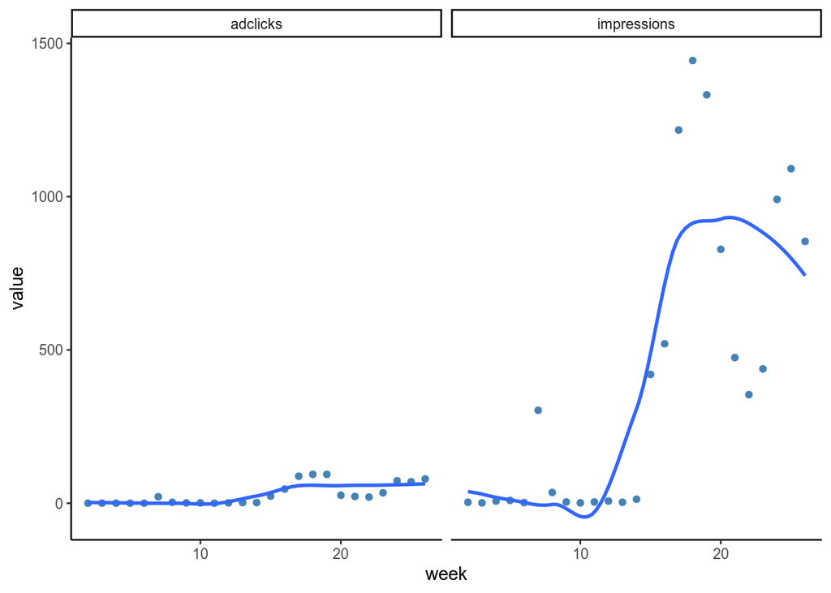

Solbriller ROI: -412.15

- Det ser ud til google har skruet ned for impressions, medmindre i har ændret i campaign?
- Når de søger på ‘solbrille styrke’ er det så for at købe solbriller med styrke eller for at få skiftet glas med styrke?

## 6.5 Countries

| country | users | transactions | conversion |
| --- | --- | --- | --- |
| Denmark | 6354 | 90 | 1.4 |
| other | 312 | 4 | 1.3 |

# 7 Spørgsmål

- Hvilke briller sender folk? Specifikke mærker? Gamle briller? Designer briller?

# 8 Forslag

## 8.1 Awareness

- Facebook, instagram og twitter ads
- Free traffic: SEO, social media etc.
- Bing ads
- A/B tests af ad campaigns
- Campaigns for standard briller, solbriller og glidende overgang
- Slå google search console til
- Åbne for 65+ igen

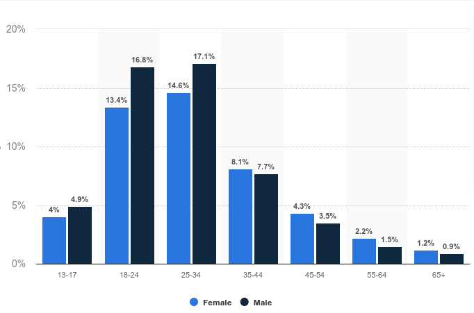

## 8.2 Interest

- A/B tests på landing page
- aktivere In-Page Analytics så man kan se hvilke knapper der trykkes på -> pain points, hvilke FAQs trykkes der på?
- aktivere mouse-hover tracking
- en specifik landing page for hhv standard, glidende overgang og solbriller
- Optimere pagespeed især på mobil: https://pagespeed.web.dev/report?url=https%3A%2F%2Fglassify.dk%2F
- vis den sikre pakke indvendigt, ikke skrive det

## 8.3 Decision / action

- trustpilot banner på siden
- Remarketing på abandonen carts
- Reducere abandonrate på glidende overgang
- Undersøge hvorfor der er lavere conversion på mobil. Måde at øge det på?
- En måde at koble alder til køb -> gør det muligt at definere kundesegmenter bedre per produktgruppe

## 8.4 Diverse

- ‘vi beregner automatisk din pd’ - tryk her for manuelt at indtaste - lave drop-down med ‘hvad er pd’? -> oprette bruger og gemme deres alder + køn
- Inspiration til prissammenligning: https://www.synoptik.dk/briller/brilleglas-og-priser/
- Lave billeder af de mest almindelige synstest og med markering om de informationer man skal bruge ved bestilling
- Sitemap i footer
- Faq bliver ikke detected som rich resultat https://search.google.com/test/rich-results/result?id=FxC3cU8KPVJZ1Yxm-NPZ9Q og inkluderes derfor ikke i “folk spørger også om” [info](https://developers.google.com/search/docs/advanced/structured-data/faqpage)
- Hvilket ecommerce plugin? woocommerce?